Olá pessoal! Kev aqui.

Essa página é um tutorial sobre como usar os pacotes `wordcloud` e `wordcloud2` no R. Pois bem, sejam bem vindos. Antes de tudo, obviamente, vamos baixar os pacotes:

```r
library(remotes)
library(wordcloud)

remotes::install_github("lchiffon/wordcloud2")
library(wordcloud2)
```

Caso o pacote `remotes` não funcione, tente trocá-lo por `devtools`:

```r
library(devtools)
library(wordcloud)

devtools::install_github("lchiffon/wordcloud2")
library(wordcloud2)
```

Baixados e carregados os pacotes, vamos lá!

# Mas afinal… do que estamos falando?

Dentro da análise de dados textuais (nota: Eu não vou chamar análise de texto aqui, pois isso poderia ser confundido com algum termo linguístico relacionado a interpretação de texto ou seja lá o que for), nuvens de palavras (wordclouds) são como um carro-chefe, pois elas fornecem uma boa visualização do que está acontecendo no texto.

Isto é, as nuvens de palavras nos mostram com que frequência as palavras aparecem no texto por meio de um gráfico, onde, quanto maior for o número de vezes que a palavra aparece, maior a frequência que ela aparece no texto.

Entendeu? É simples! Mas vamos ver como funciona na prática.

## Sobre o banco de dados

Pois bem, antes de tudo, é importante fazer todo o processo de limpeza de dados que mostramos em outro tutorial (veja a nossa pasta de tutoriais). Vamos usar o `demoFreq`, que é um banco de dados que já está limpo e vem juntamente com o pacote `wordcloud2`, e supor que já fizemos o processo de limpeza de dados necessário.

O demoFreq é um banco de dados com duas variáveis, words (palavras) e freq (frequência). E é assim que tem que estar o banco de dados para que você faça as nuvens de palavras.

```r
demoFreq
```

```
##                  word freq
## oil               oil   85
## said             said   73
## prices         prices   48
## opec             opec   42
## mln               mln   31
## the               the   26
## last             last   24
## bpd               bpd   23
## dlrs             dlrs   23
## crude           crude   21
## market         market   20
## reuter         reuter   20
## saudi           saudi   18
## will             will   18
## one               one   17
## barrel         barrel   15
## kuwait         kuwait   14
## new               new   14
## official     official   14
## pct               pct   14
## price           price   13
## barrels       barrels   11
## government government   11
## production production   11
## sheikh         sheikh   11
## industry     industry   10
## meeting       meeting   10
## minister     minister   10
## world           world   10
## also             also    9
## billion       billion    9
## futures       futures    9
##  [ reached 'max' / getOption("max.print") -- omitted 979 rows ]
```

# Conhecendo as funções

## Wordcloud

O primeiro pacote, `wordcloud`, tem os seguintes parâmetros a serem explorados:

```r
wordcloud(words,freq,scale=c(4,.5),min.freq=3,max.words=Inf,
    random.order=TRUE, random.color=FALSE, rot.per=.1,
    colors="black",ordered.colors=FALSE,use.r.layout=FALSE,
    fixed.asp=TRUE, ...)
```

As necessárias para ao código rodar são são `words` e `freq`. e as funções que vamos precisar, no geral, são as seguintes:

`words`: Coluna contendo as palavras;

`freq`: Coluna contendo o número de vezes que cada palavra aparece;

`min.freq`: Número mínimo de vezes que a palavra deve aparecer no banco, para que apareça no gráfico;

`random.order`: Define se a ordem que as palavras aparecem é aleatória ou não. Se definir como `FALSE`, as palavras retornam em frequência decrescente;

`random.color`: Define se as cores que as palavras aparecem será aleatória ou não. Se `FALSE`, o output organiza as cores segundo sua frequência;

`colors`: Define a cor que as palavras vão aparecer;

`ordered.colors`: Atribui ordem para as cores;

## Wordcloud2

O `wordcloud2` é muito parecido:

```r
wordcloud2(data, size = 1, minSize = 0, gridSize =  0,
    fontFamily = 'Segoe UI', fontWeight = 'bold',
    color = 'random-dark', backgroundColor = "white",
    minRotation = -pi/4, maxRotation = pi/4, shuffle = TRUE,
    rotateRatio = 0.4, shape = 'circle', ellipticity = 0.65,
    widgetsize = NULL, figPath = NULL, hoverFunction = NULL)
```

`data`: Agora, ao invés de você colocar a coluna e a linha que contém as palavras e a frequência, você insere o banco de dados, e o pacote identifica qual coluna representa o quê;

`size`: Tamanho relativo da fonte. Por padrão, ele é 1, mas pode ser alterado;

`rotateRatio`: Determina uma probabilidade para as palavras serem rotacionadas. É sempre entre 0 e 1. Selecione 1 para sempre rotacionar as palavras.

`minRotation`: Rotação mínima pra cada palavra (use radianos);

`maxRotation`: Rotação máxima pra cada palavra (use radianos);

`fontFamily`: Estilo da fonte do texto;

`shuffle`: Se `TRUE`, embaralha as palavras;

`backgroundColor`: Cor de fundo;

`shape`: Formato do gráfico

`ellipticity`: Define o quão ovalado o gráfico vai ser;

`figPath`: Parecido com `shape`, porém, ao invés de definir uma forma geométrica pro gráfico, você define a partir de uma imagem

# Aplicando…

Vamos começar com um exemplo simples, comparando como os pacotes funcionam na prática.

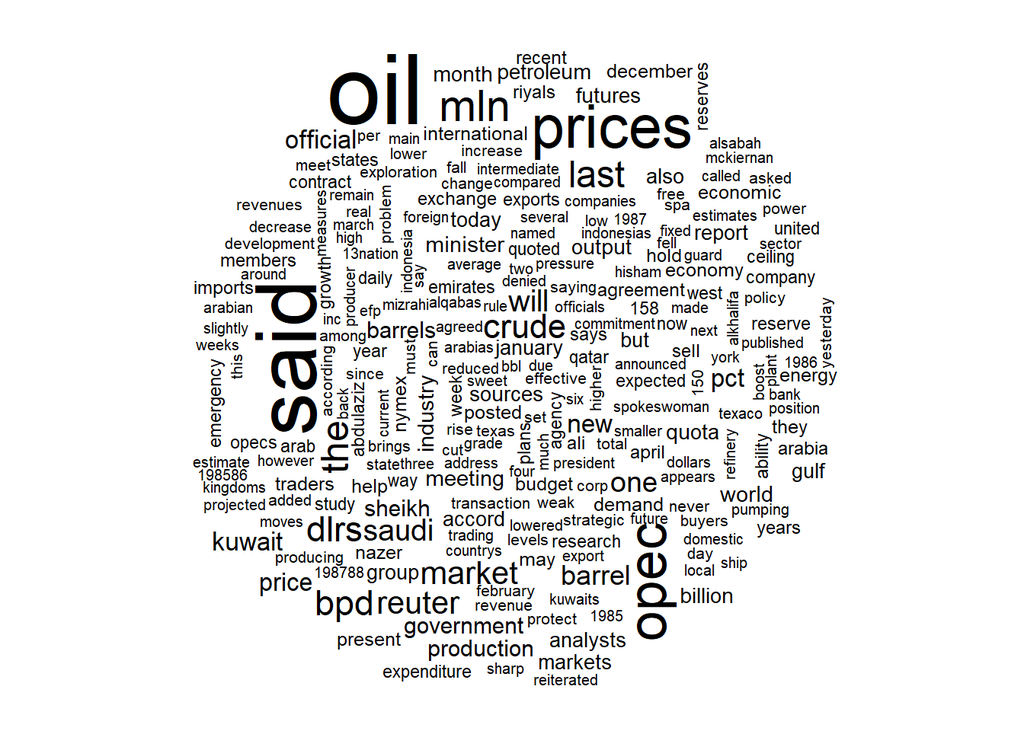

```r
wordcloud(words = demoFreq$word,
          freq = demoFreq$freq)
```

```r
wordcloud2(demoFreq)
```

[interactive chart not shown]

Bom, uma coisa que já podemos reparar de cara, é que se você posicionar o mouse em cima do gráfico do `wordcloud2`, vai reparar que é um gráfico interativo. Ao fazer isso com a palavra, ele mostra o número absoluto de vezes que a palavra aparece.

Outra diferença que podemos notar é que o `wordcloud2` por padrão é colorido, enquanto o `wordcloud` por padrão é preto. Mas claro, podemos mudar isso de uma forma bem simples:

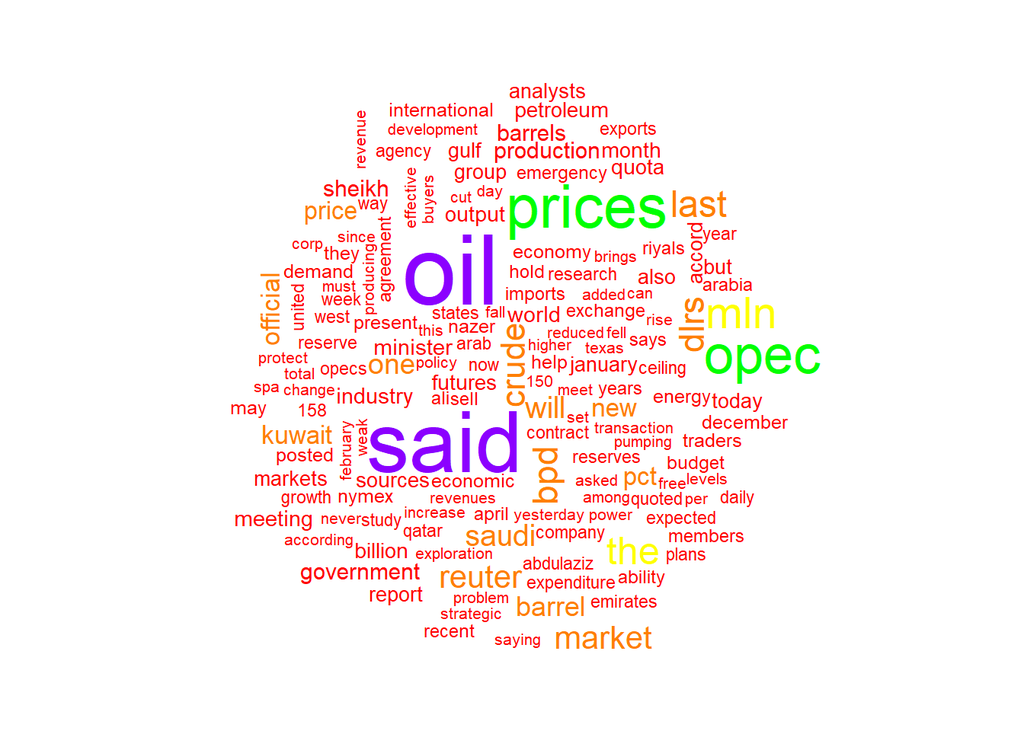

```r
wordcloud(words = demoFreq$word,
          freq = demoFreq$freq,
          color = c("#FF0000","#FF7F00","#FFFF00","#00FF00","#0000FF","#2E2B5F","#8B00FF"),
          ordered.colors = FALSE,
          min.freq = 4)
```

```r
wordcloud2(demoFreq,
    color = "black")
```

[interactive chart not shown]

Bem, mesmo mudando esses parâmetros, o `wordcloud2` parece ser muito melhor que o `wordcloud` em questões estéticas, e ser mais vasto. Por que não explorar um pouco mais ele?

A função `letterCloud()` cria uma nuvem de palavras em formato de caractere, ou palavra. Basta que a gente defina. Vamos ver como fica o gráfico em formato de “F”, que por coincidência é a primeira letra de “Campeão da Libertadores 2019”:

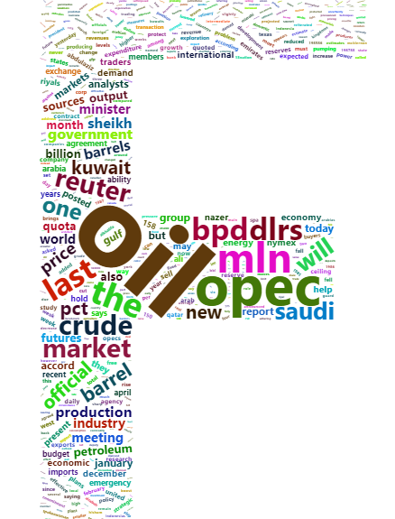

```r
letterCloud(demoFreq, backgroundColor = "transparent" word = "F", size = 0.7)
```

Mas, talvez, a coisa mais interessante (esteticamente) a ser explorada nesse pacote é o comando `figPath`. Para usá-lo, você vai precisar de uma imagem com o formato que você quer definir o gráfico. Por exemplo, suponha que você quer criar um gráfico com o formato da logo do iFood: Você pode pegar uma imagem dessa logo, em PNG, e definí-la no parâmetro.

Assim:

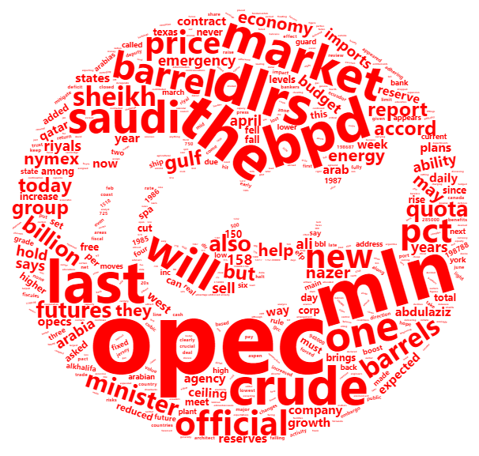

```r
figPath <- "C:/Users/.../ifood.png" # Defina o caminho do seu diretório aqui, e no final a imagem que quer, ok?

wordcloud2(demoFreq, figPath = figPath, size = 1.5, color = "red")
```

Agora, só como adendo, vale citar que esse comando é um pouco pesado, e exige um certo recurso computacional. Se o código não rodar no seu computador, experimente fazer o que você sempre faz quando o computador trava. Feche o programa e abra de novo, reinicie o computador, desative temporariamente coisas que possam estar consumindo sua RAM, ou qualquer outra coisa.

Quando conseguir rodar o código, é bom que você salve ele como arquivo HTML ou como imagem mesmo, pra não perder.

Pois bem galera, é isso que eu tinha pra mostrar, então por hoje é só. Até a próxima!